# Projekt 3

Jakub Morawski, Paweł Modzelewski

2026-01-23

## Załadowanie i przefiltrowanie danych

```r
dataH <- read.csv("spolkaH.csv", dec=".", sep=";")

dataH$date_obj <- as.Date(as.character(dataH$daty), format = "%Y%m%d")

#spróbujemy tidyverse:

dataH <- dataH |>
  mutate(
    godz6 = sprintf("%06d", godz),
    #dwukropki
    czas = paste0(
      substr(godz6, 1, 2), ":",
      substr(godz6, 3, 4), ":",
      substr(godz6, 5, 6)
    ),
    znacznik = ymd_hms(paste(daty, czas))
  ) |>
  select(znacznik, cena, vol)

dataH <- dataH |>
  filter(
    #daty
    as_date(znacznik) >= as.Date("2019-01-01") &
    as_date(znacznik) <= as.Date("2019-06-30"),

    #godziny
    znacznik >= floor_date(znacznik, "day") + hours(9) &
    znacznik <= floor_date(znacznik, "day") + hours(17) + minutes(5)
  )

dataH_sekunda <- dataH %>%
  mutate(
    znacznik_sekunda = round_date(znacznik, "second"),
    wartosc = cena*vol
  ) %>%
  group_by(znacznik_sekunda) %>%
  summarise(
    cena = sum(cena*vol, na.rm=T) / sum(vol, na.rm=T),
    vol = sum(vol, na.rm=T),
    wartosc = sum(wartosc, na.rm=T),
    ile_tickow = n(),
    .groups = "drop"
  ) %>%
  rename(znacznik = znacznik_sekunda) %>%
  filter(!is.na(cena), cena>0)

dataH_sekunda <- dataH_sekunda %>%
  mutate(data = as.Date(znacznik)) %>%
  group_by(data) %>%
  mutate(log_stopa_zwrotu = log(cena / lag(cena))) %>%
  ungroup()

stopy_zwrotuH <- dataH_sekunda %>%
  pull(log_stopa_zwrotu) %>%
  na.omit()

przetworz_5min <- function(data_sekunda) {

  #agregacja do 5-minutowych interwalow
  data_5min <- data_sekunda %>%
    mutate(
      interval_5min = floor_date(znacznik, "5 minutes")
    ) %>%
    group_by(interval_5min) %>%
    summarise(
      close_price = last(cena),
      volume = sum(vol, na.rm = TRUE),
      trans_count = sum(ile_tickow, na.rm = TRUE),
      .groups = "drop"
    ) %>%
    mutate(data_sesji = as.Date(interval_5min))

  #dla kazdego dnia znajduje ostatnia cene przed 17:00
  data_final <- data_5min %>%
    group_by(data_sesji) %>%
    arrange(interval_5min) %>%
    mutate(
      #czy dany interwał jest poza godzinami ciaglymi
      is_overtime = interval_5min >= ymd_hms(paste(data_sesji, "17:00:00")),

      #ostatnia cena z sesji ciaglej (przed 17:00)
      last_cont_price = close_price[!is_overtime][length(close_price[!is_overtime])],

      #lag: dla dogrywki użyj last_cont_price, inaczej standardowy lag
      lag_price = ifelse(is_overtime, last_cont_price, lag(close_price))
    ) %>%
    ungroup() %>%
    mutate(
      log_ret = log(close_price / lag_price),
      log_vol = log(volume)
    ) %>%
    filter(!is.na(log_ret), is.finite(log_vol)) %>%
    mutate(pora_dnia = format(interval_5min, "%H:%M")) %>%
    select(-is_overtime, -last_cont_price, -lag_price)

  return(data_final)
}

dataH_5min <- przetworz_5min(dataH_sekunda)

head(dataH_5min) %>% kbl(caption="5-minutowe stopy zwrotu") %>%
  kable_styling(bootstrap_options = c("striped", "hover", "condensed", "responsive"))
```

5-minutowe stopy zwrotu

| interval_5min | close_price | volume | trans_count | data_sesji | log_ret | log_vol | pora_dnia |
| --- | --- | --- | --- | --- | --- | --- | --- |
| 2019-01-02 09:05:00 | 8.25 | 4791 | 6 | 2019-01-02 | -0.0024213 | 8.474494 | 09:05 |
| 2019-01-02 09:10:00 | 8.26 | 27743 | 19 | 2019-01-02 | 0.0012114 | 10.230739 | 09:10 |
| 2019-01-02 09:15:00 | 8.25 | 29985 | 23 | 2019-01-02 | -0.0012114 | 10.308452 | 09:15 |
| 2019-01-02 09:20:00 | 8.26 | 26291 | 13 | 2019-01-02 | 0.0012114 | 10.176982 | 09:20 |
| 2019-01-02 09:25:00 | 8.24 | 25543 | 22 | 2019-01-02 | -0.0024242 | 10.148119 | 09:25 |
| 2019-01-02 09:30:00 | 8.23 | 10098 | 7 | 2019-01-02 | -0.0012143 | 9.220093 | 09:30 |

### Stopy zwrotu overnight

```r
overnight <- dataH_sekunda %>%
  group_by(data) %>%
  summarise(
    open_price = first(cena),
    close_price = last(cena)
  ) %>%
  mutate(
    overnight_ret = log(open_price / lag(close_price))
  )
overnight[is.na(overnight)] <- 0

head(overnight) %>% kbl(caption="Stopy zwrotu overnight") %>%
  kable_styling(bootstrap_options = c("striped", "hover", "condensed", "responsive"))
```

Stopy zwrotu overnight

| data | open_price | close_price | overnight_ret |
| --- | --- | --- | --- |
| 2019-01-02 | 8.299276 | 8.40 | 0.0000000 |
| 2019-01-03 | 8.370000 | 8.33 | -0.0035778 |
| 2019-01-04 | 8.330000 | 8.32 | 0.0000000 |
| 2019-01-07 | 8.350000 | 8.66 | 0.0035993 |
| 2019-01-08 | 8.630000 | 8.49 | -0.0034702 |
| 2019-01-09 | 8.490000 | 8.72 | 0.0000000 |

### Dzienne stopy zwrotu

```r
daily_ret <- dataH_sekunda %>%
  group_by(data) %>%
  summarise(
    close_price = last(cena),
    open_price = first(cena)
  ) %>%
  mutate(
    log_ret = log(close_price / open_price)
  )

daily_ret[is.na(daily_ret)] <- 0

head(daily_ret) %>% kbl(caption="Dzienne stopy zwrotu") %>%
  kable_styling(bootstrap_options = c("striped", "hover", "condensed", "responsive"))
```

Dzienne stopy zwrotu

| data | close_price | open_price | log_ret |
| --- | --- | --- | --- |
| 2019-01-02 | 8.40 | 8.299276 | 0.0120634 |
| 2019-01-03 | 8.33 | 8.370000 | -0.0047904 |
| 2019-01-04 | 8.32 | 8.330000 | -0.0012012 |
| 2019-01-07 | 8.66 | 8.350000 | 0.0364532 |
| 2019-01-08 | 8.49 | 8.630000 | -0.0163555 |
| 2019-01-09 | 8.72 | 8.490000 | 0.0267302 |

## Obliczanie zmienności zrealizowanej

### Sigma 1

```r
sig1 <- dataH_5min %>%
  group_by(data_sesji) %>%
  summarise(RV_intraday = sum(log_ret^2, na.rm = TRUE)) %>%
  left_join(overnight, by = c("data_sesji" = "data")) %>%
  mutate(
    value = RV_intraday + coalesce(overnight_ret^2, 0)
  ) %>%
  select(data_sesji, value)

head(sig1) %>% kbl(caption="Sigma1^2") %>%
  kable_styling(bootstrap_options = c("striped", "hover", "condensed", "responsive"))
```

Sigma1^2

| data_sesji | value |
| --- | --- |
| 2019-01-02 | 0.0001608 |
| 2019-01-03 | 0.0002213 |
| 2019-01-04 | 0.0001756 |
| 2019-01-07 | 0.0004010 |
| 2019-01-08 | 0.0003920 |
| 2019-01-09 | 0.0003811 |

### Sigma 2

```r
sig2 <- dataH_5min %>%
  group_by(data_sesji) %>%
  summarise(value = sum(log_ret ^ 2))

head(sig2) %>% kbl(caption="Sigma2^2") %>%
  kable_styling(bootstrap_options = c("striped", "hover", "condensed", "responsive"))
```

Sigma2^2

| data_sesji | value |
| --- | --- |
| 2019-01-02 | 0.0001608 |
| 2019-01-03 | 0.0002085 |
| 2019-01-04 | 0.0001756 |
| 2019-01-07 | 0.0003881 |
| 2019-01-08 | 0.0003800 |
| 2019-01-09 | 0.0003811 |

### Sigma 3

```r
c <- var(overnight$overnight_ret, na.rm = TRUE)/var(daily_ret$log_ret, na.rm = TRUE)
sig3 <- sig2 %>%
  mutate(value = value * (1+c))

head(sig3) %>% kbl(caption="Sigma3^2") %>%
  kable_styling(bootstrap_options = c("striped", "hover", "condensed", "responsive"))
```

Sigma3^2

| data_sesji | value |
| --- | --- |
| 2019-01-02 | 0.0001831 |
| 2019-01-03 | 0.0002374 |
| 2019-01-04 | 0.0001999 |
| 2019-01-07 | 0.0004417 |
| 2019-01-08 | 0.0004325 |
| 2019-01-09 | 0.0004338 |

## Porównanie oszacowań dziennej zmienności

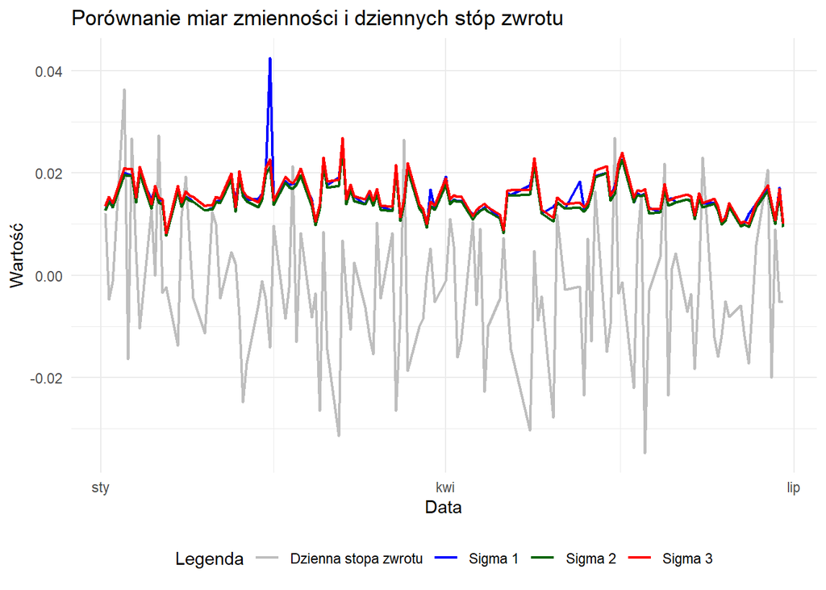

```r
sig_plot <- data.frame(
  data = sig2$data_sesji,
  sig1 = sqrt(sig1$value),
  sig2 = sqrt(sig2$value),
  sig3 = sqrt(sig3$value),
  daily_ret=daily_ret$log_ret
)

sig_plot_long <- sig_plot %>%
  pivot_longer(cols = -data, names_to = "miara", values_to = "wartosc")

ggplot(sig_plot_long, aes(x = data, y = wartosc, color = miara)) +
  geom_line(linewidth = 0.8) +
  scale_color_manual(values = c(
    "sig1" = "blue",
    "sig2" = "darkgreen",
    "sig3" = "red",
    "daily_ret" = "gray"
  ),
  labels = c(
      "sig1" = "Sigma 1",
      "sig2" = "Sigma 2",
      "sig3" = "Sigma 3",
      "daily_ret" = "Dzienna stopa zwrotu"
    )
  ) +
  labs(
    title = "Porównanie miar zmienności i dziennych stóp zwrotu",
    x = "Data",
    y = "Wartość",
    color = "Legenda"
  ) +
  theme_minimal() +
  theme(legend.position = "bottom")
```

*Analiza:*

- Wszystkie trzy miary wykazują zbliżony przebieg, co potwierdza, że głównym czynnikiem kształtującym dzienną zmienność jest aktywność handlowa w trakcie sesji giełdowej
- $\sigma_2$ systematycznie przyjmuje wartości najniższe, ponieważ ignoruje zwrot nocny, co de facto jest zaniżaniem rzeczywistej wartości.
- $\sigma_3$ znajduje się nieco ponad $\sigma_2$, ponieważ koryguje $\sigma_2$ o stałą c, mając na celu uwzględnienie zmienności z okresu zamykania giełdy, ale nie wprowadzając szumu z luki otwarcia.
- $\sigma_1$ przez większość czasu pokrywa się z pozostałymi miarami, ale widoczne na wykresie dwie zauważalne wartości odbiegające od pozostałych, wynikają z włączenia do obliczęń stopy zwrotu overnight.
- Taki skok $\sigma_1$ przy relatywnie stabilnych $\sigma_2$ i $\sigma_3$ świadczy o wystąpieniu w tym dniu bardzo dużej luki cenowej na otwarcie sesji, która zanieczyściła estymator szumem losowym.
- Widać wyraźną korelację między dzienną stopą zwrotu i wartościami miar zmienności zeralizowanej. W dniach w których dzienna stopa zwrotu przyjmuje wartości dalekie od zera, sigmy notują wzrosty.

*Wnioski:*

## Testy na występowanie skoków

### Zrealizowana dwupotęgowa wariacja

```r
bipower_var <- dataH_5min %>%
  group_by(data_sesji) %>%
  summarise(
    n = n(),
    bv_sum = sum(abs(log_ret) * abs(lag(log_ret)), na.rm = TRUE),
    value = (pi / 2) * (n / (n - 1)) * bv_sum
  ) %>%
  select(data_sesji, value)

head(bipower_var) %>% kbl(caption="Zrealizowana dwupotęgowa wariacja") %>%
  kable_styling(bootstrap_options = c("striped", "hover", "condensed", "responsive"))
```

Zrealizowana dwupotęgowa wariacja

| data_sesji | value |
| --- | --- |
| 2019-01-02 | 0.0001259 |
| 2019-01-03 | 0.0001687 |
| 2019-01-04 | 0.0001687 |
| 2019-01-07 | 0.0003084 |
| 2019-01-08 | 0.0003479 |
| 2019-01-09 | 0.0003008 |

#### Porównanie ze zmiennością zrealizowaną

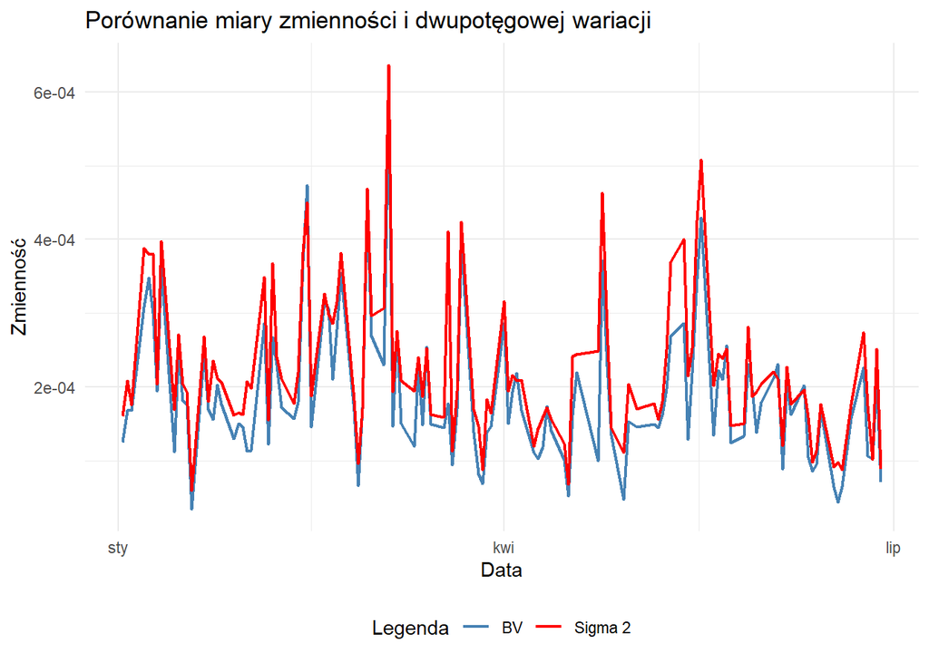

```r
var_plot <- data.frame(
  data = sig2$data_sesji,
  sig2 = sig2$value,
  bipower_var=bipower_var$value
)

var_plot_long <- var_plot %>%
  pivot_longer(cols = -data, names_to = "miara", values_to = "wartosc")

ggplot(var_plot_long, aes(x = data, y = wartosc, color = miara)) +
  geom_line(linewidth = 0.8) +
  scale_color_manual(values = c(
    "bipower_var" = "steelblue",
    "sig2" = "red"
  ),
  labels = c(
      "sig2" = "Sigma 2",
      "bipower_var" = "BV"
    )
  ) +
  labs(
    title = "Porównanie miary zmienności i dwupotęgowej wariacji",
    x = "Data",
    y = "Zmienność",
    color = "Legenda"
  ) +
  theme_minimal() +
  theme(legend.position = "bottom")
```

*Analiza:*

- Na wykresie wyraźnie widać, że linia czerwona $\sigma_2^2$ prawie cały czas przebiega ponad niebieską dwupotęgowej wariacji.
- Odstęp między liniami reprezentuje skokową składową procesu cen. Duże różnice, czyli piki $\sigma_2^2$, które nie mają odzwierciedlenia w aż tak dużym wzroście linii niebieskiej sugerują dni, w ciągu ktorych na rynku wystąpiły gwałtowne zmiany cen.
- Niebieska linia jest gładsza w porównaniu do czerwonej, bo wariacja dwupotęgowa bazuje na modułach iloczynów sąsiadujących ze sobą stóp zwrotu, co neutralizuje wpływ pojedynczych, bardzo dużych zmian cen.

*Wnioski:*

- Istnienie znaczących różnic między obiema miarami potwierdza, że proces cenowy spółki H nie jest procesem czysto ciągłym. Skoki te są najprawdopodobniej reakcją rynku na napływ rzadkich i bardzo istotnych informacji
- W celu szacowania “normalnej” zmienności wynikającej z płynnego handlu, wariancja dwupotęgowa jest bardziej precyzyjnym estymatorem.

#### Obliczenie estymatorów zintegrowanej kwartyczności

Jako estymator wykorzystana zostanie wariacja *trójpotęgowa* oraz dodatkowo *czteropotęgowa*. Dla wszystkich testów poziom istotności to $\alpha= 0.05$.

```r
mu_4_3 <- 2^(2/3) * gamma(7/6) / sqrt(pi)

TQ_3 <- dataH_5min %>%
  group_by(data_sesji) %>%
  summarise(
    n = n(),
    tq_sum = sum(
      abs(log_ret)^(4/3) * abs(lag(log_ret, 1))^(4/3) * abs(lag(log_ret, 2))^(4/3),
      na.rm = TRUE
    ),
    value = n * (mu_4_3^(-3)) * (n / (n - 2)) * tq_sum
  ) %>%
  select(data_sesji, value)

mu_1 <- sqrt(2 / pi)

RQ_4 <- dataH_5min %>%
  group_by(data_sesji) %>%
  summarise(
    n = n(),
    rq_sum = sum(
      abs(log_ret)^(1) * abs(lag(log_ret, 1))^(1) * abs(lag(log_ret, 2))^(1) * abs(lag(log_ret, 3))^(1),
      na.rm = TRUE
    ),
    # Stała mu_1 dla rozkładu normalnego to sqrt(2/pi)
    value = n * (mu_1^(-4)) * (n / (n - 3)) * rq_sum
  ) %>%
  select(data_sesji, value)

head(TQ_3) %>% kbl(caption="Zrealizowana wariacja trójpotęgowa") %>%
  kable_styling(bootstrap_options = c("striped", "hover", "condensed", "responsive"))
```

Zrealizowana wariacja trójpotęgowa

| data_sesji | value |
| --- | --- |
| 2019-01-02 | 0e+00 |
| 2019-01-03 | 0e+00 |
| 2019-01-04 | 1e-07 |
| 2019-01-07 | 1e-07 |
| 2019-01-08 | 2e-07 |
| 2019-01-09 | 1e-07 |

```r
head(RQ_4) %>% kbl(caption="Zrealizowana wariacja czteropotęgowa") %>%
  kable_styling(bootstrap_options = c("striped", "hover", "condensed", "responsive"))
```

Zrealizowana wariacja czteropotęgowa

| data_sesji | value |
| --- | --- |
| 2019-01-02 | 0e+00 |
| 2019-01-03 | 0e+00 |
| 2019-01-04 | 0e+00 |
| 2019-01-07 | 1e-07 |
| 2019-01-08 | 1e-07 |
| 2019-01-09 | 1e-07 |

### Wykres miary względnego skoku

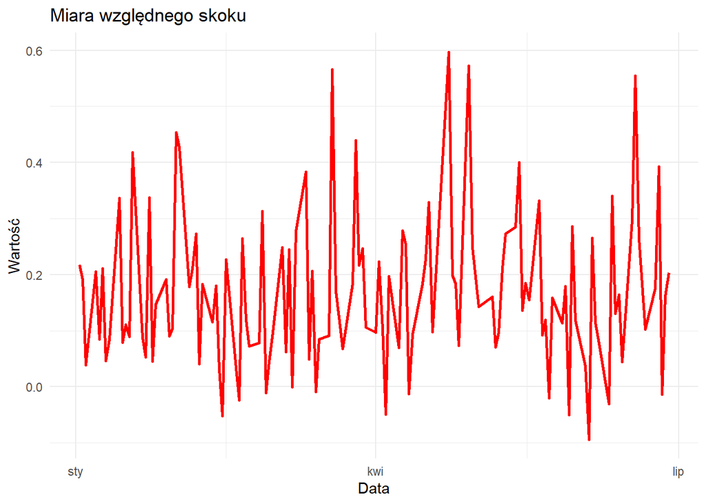

```r
rj_plot <- data.frame(
  data = sig2$data_sesji,
  rj = (sig2$value-bipower_var$value)/sig2$value
)

ggplot(rj_plot, aes(x = data, y = rj)) +
  geom_line(color = "red", linewidth = 1) +
  labs(
    title = "Miara względnego skoku",
    x = "Data",
    y = "Wartość"
  ) +
  theme_minimal()
```

*Analiza:*

- Wykres pozwala precyzyjnie określić, jaka część całkowitej zmienności procesu cen wynika z nagłych skoków
- Wartości na osi pionowej wskazują udział procentowy skokowej części procesu w całkowitej zmienności dziennej. Na wykresie widać dni, w których skoki odpowiadały za ponad 50-60% całkowitej zmienności, to piki w okolicy marca i maja i w końcówce czerwca.
- Miara charakteryzuje się dużą fluktuacją, co sugeruje, że mechanizm generujący ceny jest niejednorodny. Występuje dominacja procesów ciągłych, która jest często przerywana przez gwałtowne impulsy związane z informacją z rynku. Zatem trzy wspomniane piki to momenty w których rzadkie i niespodziewane zdarzenia przyniosły “niespodziankę” inwestorom.

### Test oparty na różnicach

#### Obliczenie statystyki testowej dla wariacji trójpotęgowej jako estymator zintegrowanej kwartyczności

```r
theta <- (pi^2/4)+pi-5
BNSr <- (sqrt(length(sig2)) * (sig2$value-bipower_var$value))/sqrt(theta*TQ_3$value)
jumpDif <- BNSr > qnorm(0.95)
cat("Liczba skoków wykryta:", sum(jumpDif), "\n")
```

```
## Liczba skoków wykryta: 2
```

Wykres:

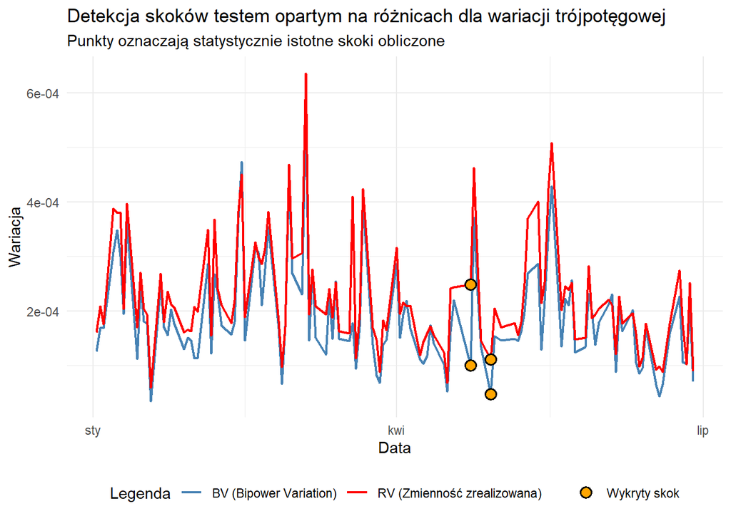

```r
jump_long_dif <- var_plot_long %>%
  left_join(data.frame(data = var_plot$data, jump = jumpDif), by = "data") %>%
  filter(jump == TRUE)

# 2. Wykres
ggplot(var_plot_long, aes(x = data, y = wartosc, color = miara)) +
  geom_line(linewidth = 0.8) +
  geom_point(
    data = jump_long_dif,
    aes(fill = "Wykryty skok"),
    color = "black",
    shape = 21,
    size = 3,
    stroke = 1
  ) +
  scale_color_manual(
    values = c(
      "bipower_var" = "steelblue",
      "sig2" = "red"
    ),
    labels = c(
      "sig2" = "RV (Zmienność zrealizowana)",
      "bipower_var" = "BV (Bipower Variation)"
    )
  ) +
  scale_fill_manual(
    name = NULL,
    values = c("Wykryty skok" = "orange")
  ) +
  labs(
    title = "Detekcja skoków testem opartym na różnicach dla wariacji trójpotęgowej",
    subtitle = "Punkty oznaczają statystycznie istotne skoki obliczone",
    x = "Data",
    y = "Wariacja",
    color = "Legenda"
  ) +
  theme_minimal() +
  theme(legend.position = "bottom")
```

*Analiza:*

*Wnioski:*

- Wyniki potwierdzają, że test oparty na różnicach liniowych może czasami przeszacowywać lub błędnie identyfikować liczbę skoków w zależności od zachowania estymatora kwartyczności.
- Wykryte skoki na przełomie kwietnia i maja sugerują wpływ specyficznych informacji giełdowych, które zmieniły cenę gwałtownie. Mogły to być takie zdarzenia jak publikacja wyników finansowych spółki, czy jakiś ważny komunikat publiczny.

#### Obliczenie statystyki testowej dla wariacji czteropotęgowej jako estymator zintegrowanej kwartyczności

```r
theta <- (pi^2/4)+pi-5
BNSr <- (sqrt(length(sig2)) * (sig2$value-bipower_var$value))/sqrt(theta*RQ_4$value)
jumpDif <- BNSr > qnorm(0.95)
cat("Liczba skoków wykryta:", sum(jumpDif), "\n")
```

```
## Liczba skoków wykryta: 4
```

Wykres:

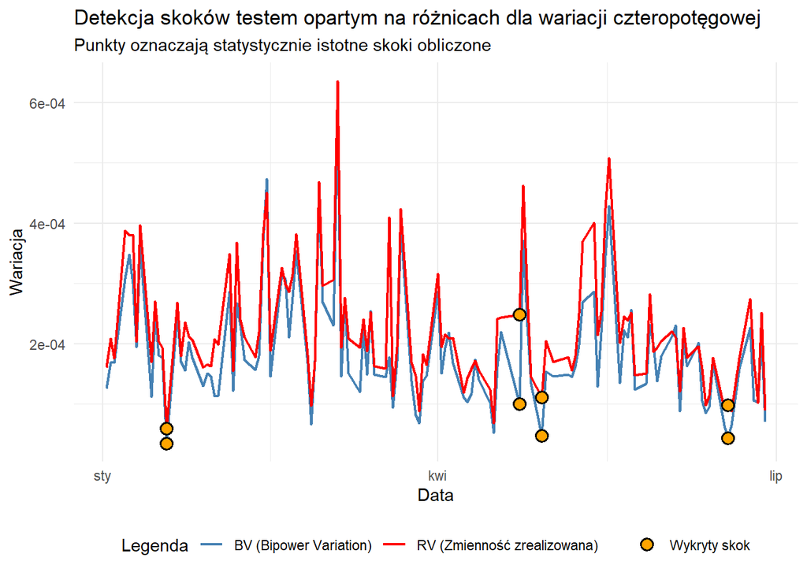

```r
jump_long_dif <- var_plot_long %>%
  left_join(data.frame(data = var_plot$data, jump = jumpDif), by = "data") %>%
  filter(jump == TRUE)

# 2. Wykres
ggplot(var_plot_long, aes(x = data, y = wartosc, color = miara)) +
  geom_line(linewidth = 0.8) +
  geom_point(
    data = jump_long_dif,
    aes(fill = "Wykryty skok"),
    color = "black",
    shape = 21,
    size = 3,
    stroke = 1
  ) +
  scale_color_manual(
    values = c(
      "bipower_var" = "steelblue",
      "sig2" = "red"
    ),
    labels = c(
      "sig2" = "RV (Zmienność zrealizowana)",
      "bipower_var" = "BV (Bipower Variation)"
    )
  ) +
  scale_fill_manual(
    name = NULL,
    values = c("Wykryty skok" = "orange")
  ) +
  labs(
    title = "Detekcja skoków testem opartym na różnicach dla wariacji czteropotęgowej",
    subtitle = "Punkty oznaczają statystycznie istotne skoki obliczone",
    x = "Data",
    y = "Wariacja",
    color = "Legenda"
  ) +
  theme_minimal() +
  theme(legend.position = "bottom")
```

*Analiza:*

*Wnioski:*

- Wybór estymatora kwartyczności istotnie wpływa na wynik końcowy. Aby uzyskać najbardziej stabilny obraz, przeprowadzono także testy logarytmiczne, które są mniej wrażliwe na ekstremalne piki zmienności w mianowniku.

### Test oparty na różnicach logarytmów

#### Obliczenie statystyki testowej dla wariacji trójpotęgowej jako estymator zintegrowanej kwartyczności

```r
BNSl <- (sqrt(length(sig2)) * (log(sig2$value)-log(bipower_var$value)))/sqrt(theta*TQ_3$value/bipower_var$value^2)
jumpLog <- BNSl > qnorm(0.95)
cat("Liczba skoków wykryta:", sum(sum(jumpLog)), "\n")
```

```
## Liczba skoków wykryta: 1
```

Wykres:

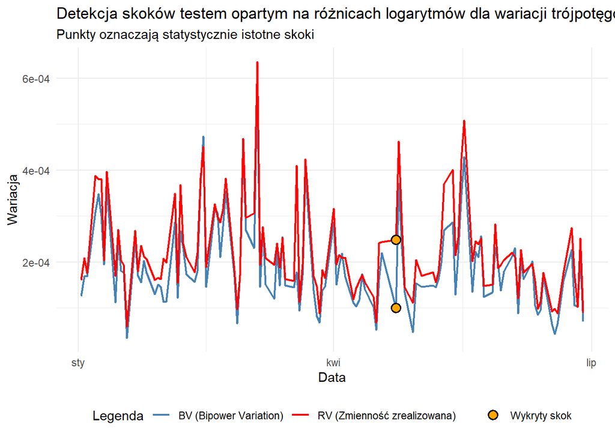

```r
skoki_long <- var_plot_long %>%
  left_join(data.frame(data = var_plot$data, jump = jumpLog), by = "data") %>%
  filter(jump == TRUE)

# 2. Wykres
ggplot(var_plot_long, aes(x = data, y = wartosc, color = miara)) +
  geom_line(linewidth = 0.8) +
  geom_point(
    data = skoki_long,
    aes(fill = "Wykryty skok"),
    color = "black",
    shape = 21,
    size = 3,
    stroke = 1
  ) +
  scale_color_manual(
    values = c(
      "bipower_var" = "steelblue",
      "sig2" = "red"
    ),
    labels = c(
      "sig2" = "RV (Zmienność zrealizowana)",
      "bipower_var" = "BV (Bipower Variation)"
    )
  ) +
  scale_fill_manual(
    name = NULL,
    values = c("Wykryty skok" = "orange")
  ) +
  labs(
    title = "Detekcja skoków testem opartym na różnicach logarytmów dla wariacji trójpotęgowej",
    subtitle = "Punkty oznaczają statystycznie istotne skoki",
    x = "Data",
    y = "Wariacja",
    color = "Legenda"
  ) +
  theme_minimal() +
  theme(legend.position = "bottom")
```

*Analiza:*

- Transformacja logarytmiczna niejako ściąga ekstremalne wartości, co sprawia, że statystyka testowa jest mniej podatna na odrzucenie hipotezy zerowej o braku skoków przy nawet umiarkowanych odchyleniach. Czyni to ten test bardzo rygorystycznym.
- Wspomniany wcześniej wysoki pik $RV$ niedaleko na prawo w około 3/4 wykresu znów nie został wykryty jako statystycznie istotny skok. Test logarytmiczny potwierdza diagnozę, że tamto zdarzenie było raczej wynikiem ekstremalnie wysokiej wariancji procesu ciągłego a nie pojedynczym skokiem który mógłby zaburzyć strukturę logarytmiczną szeregu.

*Wnioski:*

- Test oparty na różnicach logarytmów ma najlepsze własności w próbach o skończonej wielkości, a fakt, że wykrył on tylko jeden skok, który wykrywają wszystkie przeprowadzone dotychczas testy sugeruje, że tylko to konkretne zdarzenie na przełomie kwietnia i maja miało charakter „czystego” skoku cenowego, a pozostałe sygnały z innych testów mogły być błędami I rodzaju wynikającymi ze specyfiki liniowych statystyk.
- Wykorzystanie wariacji trójpotęgowej jako estymatora zintegrowanej kwartyczności w połączeniu z logarytmami tworzy bardzo stabilne narzędzie diagnostyczne. Okazuje sie, że gwatowne ruchy cenowe spółki H mają podłoże w zmienności ciągłej, a nie w skokowych napływach informacji z rynku. Świadczy to o wysokiej płynności spółki.

#### Obliczenie statystyki testowej dla wariacji czteropotęgowej jako estymator zintegrowanej kwartyczności

```r
BNSl <- (sqrt(length(sig2)) * (log(sig2$value)-log(bipower_var$value)))/sqrt(theta*RQ_4$value/bipower_var$value^2)
jumpLog <- BNSl > qnorm(0.95)
cat("Liczba skoków wykryta:", sum(sum(jumpLog)), "\n")
```

```
## Liczba skoków wykryta: 2
```

Wykres:

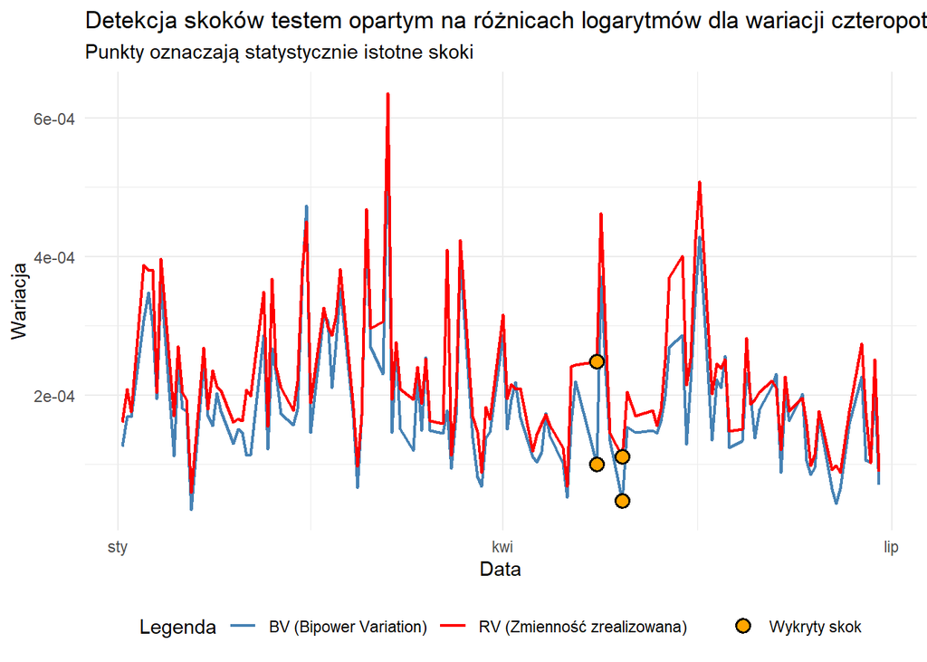

```r
skoki_long <- var_plot_long %>%
  left_join(data.frame(data = var_plot$data, jump = jumpLog), by = "data") %>%
  filter(jump == TRUE)

# 2. Wykres
ggplot(var_plot_long, aes(x = data, y = wartosc, color = miara)) +
  geom_line(linewidth = 0.8) +
  geom_point(
    data = skoki_long,
    aes(fill = "Wykryty skok"),
    color = "black",
    shape = 21,
    size = 3,
    stroke = 1
  ) +
  scale_color_manual(
    values = c(
      "bipower_var" = "steelblue",
      "sig2" = "red"
    ),
    labels = c(
      "sig2" = "RV (Zmienność zrealizowana)",
      "bipower_var" = "BV (Bipower Variation)"
    )
  ) +
  scale_fill_manual(
    name = NULL,
    values = c("Wykryty skok" = "orange")
  ) +
  labs(
    title = "Detekcja skoków testem opartym na różnicach logarytmów dla wariacji czteropotęgowej",
    subtitle = "Punkty oznaczają statystycznie istotne skoki",
    x = "Data",
    y = "Wariacja",
    color = "Legenda"
  ) +
  theme_minimal() +
  theme(legend.position = "bottom")
```

*Analiza:*

- W porównaniu do poprzedniego testu logarytmicznego, który wykrył tylko jeden skok, zastosowanie wariacji czteropotęgowej pozwoliło zidentyfikować dwa dni ze statystycznie istotnymi skokami.
- Jej zastosowanie w mianowniku statystyki testowej często skutkuje wyższą mocą testu niż w przypadku wariacji trójpotęgowej, co tłumaczy wykrycie dodatkowego skoku przy zachowaniu tego samego poziomu istotności $\alpha=0.05$

*Wnioski:*

- Test oparty na różnicach logarytmów ma najlepsze własności w próbach o skończonej wielkości. Jest on mniej skłonny do generowania “fałszywych alarmów” niż testy liniowe, które w poprzednich próbach wykrywały więcej skoków.
- Ponownie niewykryty wcześniej wspomniany pik potwierdza, że tamto zdarzenie było raczej wynikiem ekstremalnie wysokiej wariancji procesu ciągłego.

### Test ilorazowy

#### Obliczenie statystyki testowej dla wariacji trójpotęgowej jako estymator zintegrowanej kwartyczności

```r
BNSi <- (sqrt(length(sig2)) * (log(sig2$value)-log(bipower_var$value)))/sqrt(theta*pmax(1, TQ_3$value / (bipower_var$value^2)))
jumpQ <- BNSi > qnorm(0.95)
cat("Liczba skoków wykryta:", sum(sum(jumpQ)), "\n")
```

```
## Liczba skoków wykryta: 1
```

Wykres:

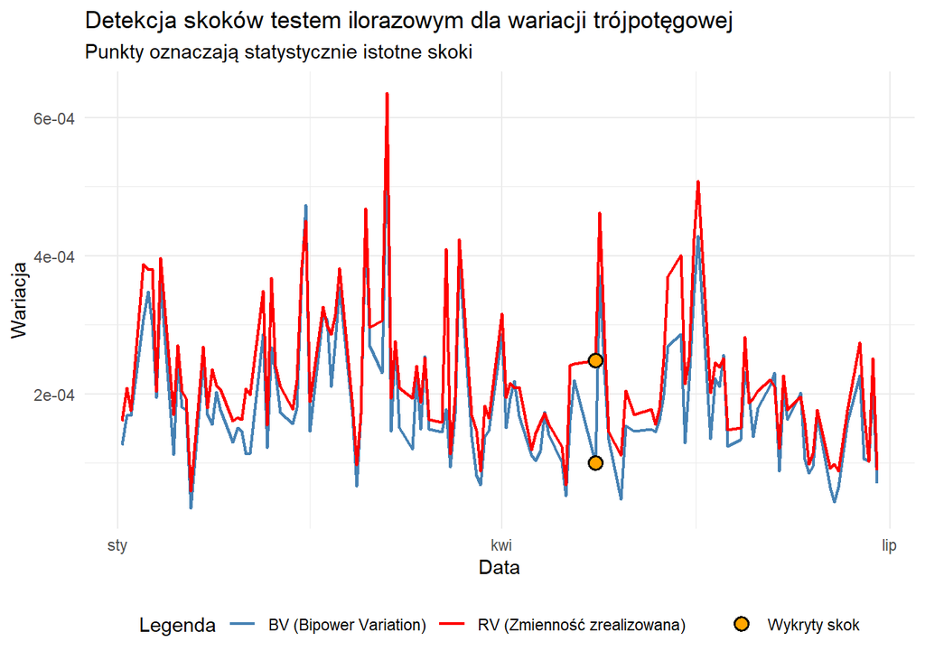

```r
skoki_long <- var_plot_long %>%
  left_join(data.frame(data = var_plot$data, jump = jumpQ), by = "data") %>%
  filter(jump == TRUE)

# 2. Wykres
ggplot(var_plot_long, aes(x = data, y = wartosc, color = miara)) +
  geom_line(linewidth = 0.8) +
  geom_point(
    data = skoki_long,
    aes(fill = "Wykryty skok"),
    color = "black",
    shape = 21,
    size = 3,
    stroke = 1
  ) +
  scale_color_manual(
    values = c(
      "bipower_var" = "steelblue",
      "sig2" = "red"
    ),
    labels = c(
      "sig2" = "RV (Zmienność zrealizowana)",
      "bipower_var" = "BV (Bipower Variation)"
    )
  ) +
  scale_fill_manual(
    name = NULL,
    values = c("Wykryty skok" = "orange")
  ) +
  labs(
    title = "Detekcja skoków testem ilorazowym dla wariacji trójpotęgowej",
    subtitle = "Punkty oznaczają statystycznie istotne skoki",
    x = "Data",
    y = "Wariacja",
    color = "Legenda"
  ) +
  theme_minimal() +
  theme(legend.position = "bottom")
```

*Analiza:*

- Test ilorazowy wykrył dokładnie ten sam skok na przełomie kwietnia i maja, co test oparty o różnice logarytmów, przy tym samym IQ
- Podobnie jak test logarytmiczny, test ilorazowy zignorował ekstremalny pik zmienności zrealizowanej ($RV$) w 3/4 badanego okresu oraz mniejsze odchylenia, które były uznawane za skoki przez testy liniowe.
- Statystyka testu ilorazowego, wykorzystująca funkcję $max$ w mianowniku jest szczególnie rygorystyczna przy dużej zmienności, co sprawia, że wykrycie skoku w konkretnym dniu jest bardzo selektywne.

*Wnioski:*

- Fakt, że dwa zaawansowane testy wskazują tylko ten sam dzień, sugeruje, że tylko to konkretne zdarzenie na przełomie kwietnia i maja jest rzeczywistym skokiem cenowym. Inne piki zmienności są prawdopodobnie wynikiem bardzo intensywnego handlu ciągłego.
- Porównanie wyników testów pokazuje, że testy ilorazowe i logarytmiczne są mniej podatne na błędy I rodzaju

#### Obliczenie statystyki testowej dla wariancji czteropotęgowej jako estymator zintegrowanej kwartyczności

```r
BNSi <- (sqrt(length(sig2)) * (log(sig2$value)-log(bipower_var$value)))/sqrt(theta*pmax(1, RQ_4$value / (bipower_var$value^2)))
jumpQ <- BNSi > qnorm(0.95)
cat("Liczba skoków wykryta:", sum(sum(jumpQ)), "\n")
```

```
## Liczba skoków wykryta: 1
```

Wykres:

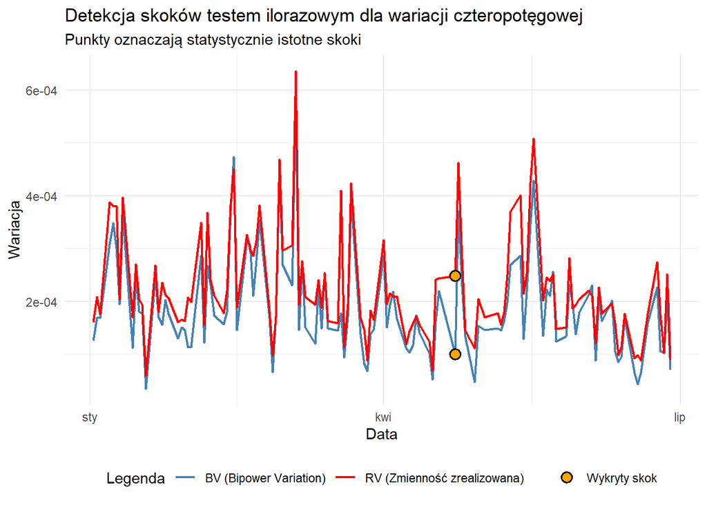

```r
skoki_long <- var_plot_long %>%
  left_join(data.frame(data = var_plot$data, jump = jumpQ), by = "data") %>%
  filter(jump == TRUE)

# 2. Wykres
ggplot(var_plot_long, aes(x = data, y = wartosc, color = miara)) +
  geom_line(linewidth = 0.8) +
  geom_point(
    data = skoki_long,
    aes(fill = "Wykryty skok"),
    color = "black",
    shape = 21,
    size = 3,
    stroke = 1
  ) +
  scale_color_manual(
    values = c(
      "bipower_var" = "steelblue",
      "sig2" = "red"
    ),
    labels = c(
      "sig2" = "RV (Zmienność zrealizowana)",
      "bipower_var" = "BV (Bipower Variation)"
    )
  ) +
  scale_fill_manual(
    name = NULL,
    values = c("Wykryty skok" = "orange")
  ) +
  labs(
    title = "Detekcja skoków testem ilorazowym dla wariacji czteropotęgowej",
    subtitle = "Punkty oznaczają statystycznie istotne skoki",
    x = "Data",
    y = "Wariacja",
    color = "Legenda"
  ) +
  theme_minimal() +
  theme(legend.position = "bottom")
```

*Analiza:*

- Test ilorazowy używający wariacji czteropotęgowej wykrył dokładnie ten sam skok na przełomie kwietnia i maja, co wersja używająca wariacji trójpotęgowej. Fakt, że zmiana estymatora kwartyczności na teoretycznie bardziej odporny $QQ$ nie zmieniła wyniku, świadczy o bardzo wysokiej istotności statystycznej tego konkretnego zdarzenia
- Podobnie jak pozostałe testy, ten również zignorował ekstremalny pik zmienności zrealizowanej ($RV$) w 3/4 badanego okresu oraz mniejsze odchylenia, które były uznawane za skoki przez testy liniowe.
- Statystyka testu ilorazowego, wykorzystująca funkcję $max$ w mianowniku jest szczególnie rygorystyczna przy dużej zmienności, co sprawia, że wykrycie skoku w konkretnym dniu jest bardzo selektywne.

*Wnioski:*